# BabyNamesAnalysis

```python
import pandas as pd
import numpy as np
```

## Task 1:Data Acquisition and Integration

```python
health_data=pd.read_csv('health_survey.csv',encoding='latin')

health_data=health_data.drop(['Unnamed: 0','p.value.16.15','p.value.16.14','p.value.16.13','p.value.16.12','p.value.16.11','p.value.16.06','p.value.16.07'],axis='columns')

health_data=health_data.rename(index=str,columns={'short.description':'description','percent.16':'2016','percent.15':'2015','percent.14':'2014','percent.13':'2013','percent.12':'2012','percent.11':'2011','percent.06':'2006','percent.07':'2007'})

health_data.head()
```

|  | population | description | group | 2016 | 2015 | 2014 | 2013 | 2012 | 2011 | 2006 | 2007 |
| --- | --- | --- | --- | --- | --- | --- | --- | --- | --- | --- | --- |
| 0 | adults | Physically active | Total | 50.2 | 47.7 | 50.7 | 52.1 | 51.7 | 54.4 | 52.0 | NaN |
| 1 | adults | Physically active | Men | 53.0 | 51.0 | 55.2 | 55.2 | 55.8 | 57.3 | 55.5 | NaN |
| 2 | adults | Physically active | Women | 47.6 | 44.5 | 46.5 | 49.1 | 47.9 | 51.7 | 48.8 | NaN |
| 3 | adults | Physically active | 15-17 | 47.1 | 41.7 | 49.6 | 46.7 | 52.7 | 58.1 | 58.6 | NaN |
| 4 | adults | Physically active | 18-24 | 53.5 | 49.7 | 52.6 | 53.7 | 54.9 | 57.4 | 55.3 | NaN |

# Q1:Filtering

**Using isin method to filter column attributes**

```python
#health_data['description'].unique()
#health_data['group'].unique()
#health_data['population'].unique()
health_data_new=health_data[(health_data['population'].isin(['adults'])) & (health_data['group'].isin(['Total'])) &
                           (health_data['description'].isin(['Amphetamine use (16-64 years)','Cannabis use','Psychological distress',
                                                             'Daily smokers','Physically active','Heart failure']))]
health_data_new
```

|  | population | description | group | 2016 | 2015 | 2014 | 2013 | 2012 | 2011 | 2006 | 2007 |
| --- | --- | --- | --- | --- | --- | --- | --- | --- | --- | --- | --- |
| 0 | adults | Physically active | Total | 50.2 | 47.7 | 50.7 | 52.1 | 51.7 | 54.4 | 52.0 | NaN |
| 92 | adults | Amphetamine use (16-64 years) | Total | 1.0 | 1.1 | 0.9 | 1.1 | 0.9 | 0.9 | NaN | 2.1 |
| 224 | adults | Cannabis use | Total | 11.6 | 11.3 | 9.9 | 10.5 | 9.4 | 8.0 | NaN | NaN |
| 292 | adults | Daily smokers | Total | 13.8 | 14.2 | 15.0 | 15.7 | 15.6 | 16.3 | 18.3 | NaN |
| 909 | adults | Heart failure | Total | 2.1 | 1.9 | 1.9 | 2.0 | 2.1 | 2.0 | 2.1 | NaN |
| 1087 | adults | Psychological distress | Total | 7.6 | 6.8 | 6.2 | 6.2 | 6.1 | 4.5 | 6.6 | NaN |

# Wrangling and reshaping:

```python
health_data_new
health_data_new_2=health_data_new.reset_index(drop=True)
health_data_new_2=health_data_new_2.drop(['population','group'],axis=1)
health_data_new_2=health_data_new_2.set_index(['description'])
health_data_new_2.columns.names=['Year']
health_data_new_2=health_data_new_2.T
health_data_new_2=health_data_new_2.sort_index()
health_data_new_2
```

| description Year | Physically active | Amphetamine use (16-64 years) | Cannabis use | Daily smokers | Heart failure | Psychological distress |
| --- | --- | --- | --- | --- | --- | --- |
| 2006 | 52.0 | NaN | NaN | 18.3 | 2.1 | 6.6 |
| 2007 | NaN | 2.1 | NaN | NaN | NaN | NaN |
| 2011 | 54.4 | 0.9 | 8.0 | 16.3 | 2.0 | 4.5 |
| 2012 | 51.7 | 0.9 | 9.4 | 15.6 | 2.1 | 6.1 |
| 2013 | 52.1 | 1.1 | 10.5 | 15.7 | 2.0 | 6.2 |
| 2014 | 50.7 | 0.9 | 9.9 | 15.0 | 1.9 | 6.2 |
| 2015 | 47.7 | 1.1 | 11.3 | 14.2 | 1.9 | 6.8 |
| 2016 | 50.2 | 1.0 | 11.6 | 13.8 | 2.1 | 7.6 |

# Data wrangle function:

```python
def data_wrangle_shape(population,group,description):
        data=health_data[(health_data['population'].isin([population])) & (health_data['group'].isin([group])) &
                          (health_data['description'].isin(description))]
        data=data.reset_index(drop=True)
        data=data.drop(['population','group'],axis=1)
        data=data.set_index(['description'])
        data.columns.names=['Year']
        data=data.T
        data=data.sort_index()
        return data
health_data_women=data_wrangle_shape(population='adults',group='Women',description=['Current smokers','Cannabis use','Psychological distress','Daily smokers','Physically active'])

health_data_men=data_wrangle_shape(population='adults',group='Men',description=['Current smokers','Cannabis use','Psychological distress','Daily smokers','Physically active'])

Smokers_current=data_wrangle_shape(population='adults',group='Total',description=['Current smokers'])

Smokers_current=Smokers_current.fillna(0)
```

# Plotting:

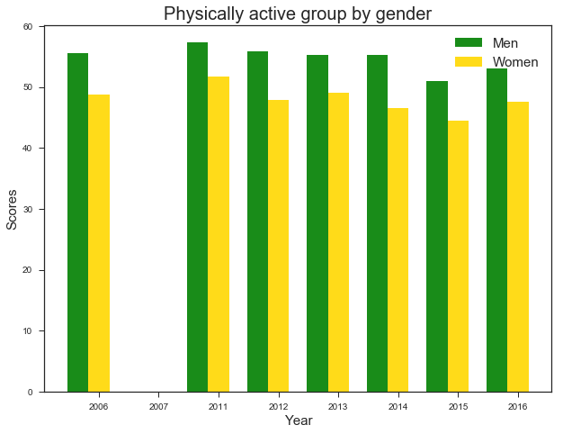

```python
import matplotlib.pyplot as plt
import seaborn as sns
from pandas import Series
sns.set(style="ticks")
from pylab import rcParams
%matplotlib inline

plot_years=len(health_data_men.index)
x=health_data_men.loc[:,'Physically active']
plt.rcParams['figure.figsize']=(10,8)
plt.rcParams.update({'font.size':50})
y=health_data_women.loc[:,'Physically active']
bar_width = 0.35
ypos=np.arange(plot_years)
opacity = 0.9
error_config = {'ecolor': '0.3'}
fig, ax = plt.subplots()
#rects1 = plt.bar(index, means_frank, bar_width,
x = ax.bar(ypos, x, bar_width, color='g',alpha=opacity,label='Men')
y = ax.bar(ypos + bar_width, y, bar_width, color='gold',alpha=opacity,label='Women')

ax.set_xlabel('Year',fontsize=15)
ax.set_ylabel('Scores',fontsize=15)
ax.set_title('Physically active group by gender',fontsize=20)
plt.xticks(ypos + bar_width, (health_data_men.index))

ax.legend(fontsize='15')

fig.tight_layout()
plt.show()
```

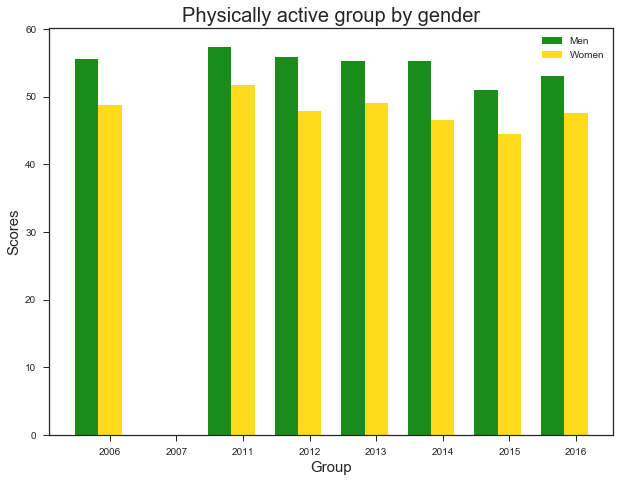

```python
plot_years=len(health_data_men.index)
x=health_data_men.loc[:,'Physically active']
plt.rcParams['figure.figsize']=(10,8)
plt.rcParams.update({'font.size':50})
y=health_data_women.loc[:,'Physically active']
bar_width = 0.35
ypos=np.arange(plot_years)
opacity = 0.9
error_config = {'ecolor': '0.3'}
fig, ax = plt.subplots()
#rects1 = plt.bar(index, means_frank, bar_width,
x = ax.bar(ypos, x, bar_width, color='g',alpha=opacity,label='Men')
y = ax.bar(ypos + bar_width, y, bar_width, color='gold',alpha=opacity,label='Women')

ax.set_xlabel('Group',fontsize=15)
ax.set_ylabel('Scores',fontsize=15)
ax.set_title('Physically active group by gender',fontsize=20)
plt.xticks(ypos + bar_width, (health_data_men.index))

ax.legend()

fig.tight_layout()
plt.show()
```

### Findings:

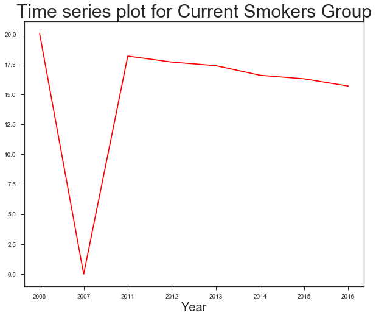

```python
fig = plt.figure()
plt.tight_layout()
ax1 = fig.add_subplot(111)
ax1.set_title('Time series plot for Current Smokers Group',fontsize='30')
plt.xlabel('Year',fontsize=20)
x1=Smokers_current.index
y1=Smokers_current['Current smokers']
ax1.plot(x1,y1,color='r')
```

### Findings:

**The plot shows there is a decline in the amount of current smokers year by year.Factors affecting this may include increase in packaged cigarettes and also the government initiative to make New Zealand smoke-free.2007 has a missing value.**

# Grouping and Plotting NZ TOP 100 Baby Names Dataset

**For the below dataset for babynames:**

**The dataset is split using groupby in regards to sex 'Male' and 'female' and stored in different objects**

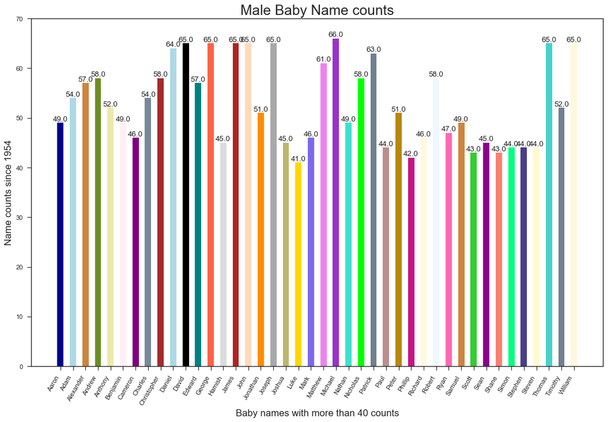

```python
baby_names = pd.read_csv('baby_names.csv')
baby_names_new=baby_names.reset_index(drop=True)
baby_names_new=baby_names_new.set_index(['year'])
baby_names_new=baby_names_new.sort_index()
baby_names_male=dict(list(baby_names_new.groupby('sex')))['Male']
baby_names_female=dict(list(baby_names_new.groupby('sex')))['Female']
#baby_names_female['Name'].unique()
#baby_names_male['Name'].unique()
#baby_names_female.Name.value_counts()
#baby_names_male.Name.value_counts()
import random
plt.rcParams['figure.figsize']=(10,8)
plt.rcParams.update({'font.size':50})
Male_Group = baby_names_male.groupby('Name').size().reset_index(name='counts')
Male_Group=Male_Group[Male_Group.counts>40]
n = Male_Group['Name'].unique().__len__()+1
all_colors = list(plt.cm.colors.cnames.keys())
random.seed(100)
c = random.choices(all_colors, k=n)
plt.figure(figsize=(16,10), dpi= 80)
plt.bar(Male_Group['Name'], Male_Group['counts'], color=c, width=.5)
for i, val in enumerate(Male_Group['counts'].values):
    plt.text(i, val, float(val), horizontalalignment='center', verticalalignment='bottom', fontdict={'fontweight':500, 'size':12})

# Decoration
plt.gca().set_xticklabels(Male_Group['Name'], rotation=60, horizontalalignment= 'right')
plt.title("Male Baby Name counts", fontsize=22)
plt.ylabel('Name counts since 1954',fontsize=15)
plt.xlabel('Baby names with more than 40 counts',fontsize=15)
plt.ylim(0, 70)
plt.show()
```

**Male baby names with more than 40 counts has been displayed above as a bar chart where the highest count is for the name Michael.**

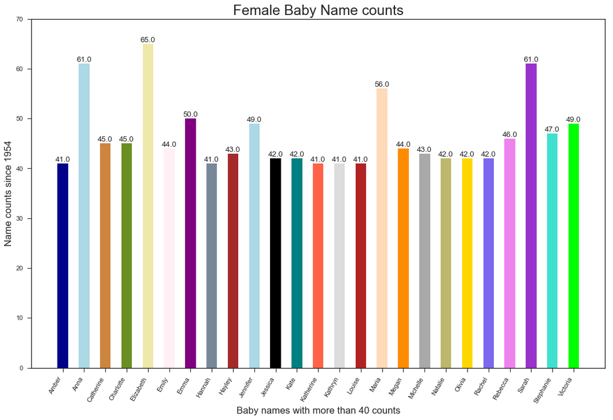

```python
Female_Group = baby_names_female.groupby('Name').size().reset_index(name='counts')
Female_Group=Female_Group[Female_Group.counts>40]
n = Female_Group['Name'].unique().__len__()+1
all_colors = list(plt.cm.colors.cnames.keys())
random.seed(100)
c = random.choices(all_colors, k=n)
plt.figure(figsize=(16,10), dpi= 80)
plt.bar(Female_Group['Name'], Female_Group['counts'], color=c, width=.5)
for i, val in enumerate(Female_Group['counts'].values):
    plt.text(i, val, float(val), horizontalalignment='center', verticalalignment='bottom', fontdict={'fontweight':500, 'size':12})

# Decoration
plt.gca().set_xticklabels(Female_Group['Name'], rotation=60, horizontalalignment= 'right')
plt.title("Female Baby Name counts", fontsize=22)
plt.ylabel('Name counts since 1954',fontsize=15)
plt.xlabel('Baby names with more than 40 counts',fontsize=15)
plt.ylim(0, 70)
plt.show()
```

**Among female baby names most frequently appearing was Elizabeth with 65 counts since 1954. In comparison to the Male baby names, the number of female baby names were less in terms of counts more than 40.**

```
Text(0,0.5,'Scores')
```

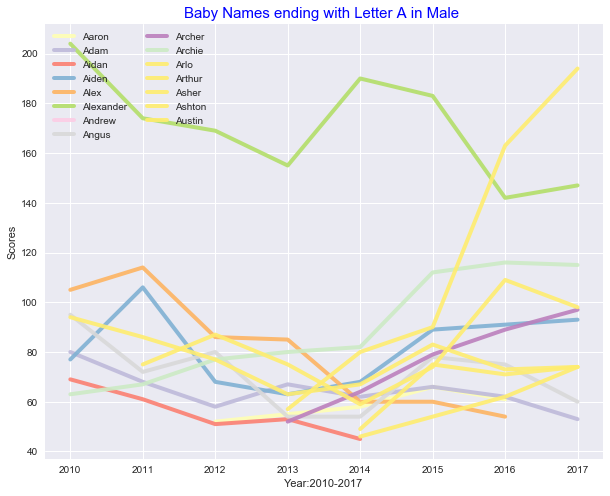

```python
#dict(list(baby_names_new.groupby('Name')))['Male']
import sys
import matplotlib.cm as cm
plt.rcParams['figure.figsize']=(10,8)
plt.rcParams.update({'font.size':20})
plt.style.use('seaborn-darkgrid')


df=baby_names_male.reset_index()
df=baby_names_male.drop(['sex'],axis=1)
df=df[(df.index>=2010)&(df.index<=2017)&(df['Name'].astype(str).str[0]=='A')]
df=df.pivot_table(index=['year'],columns='Name',values='No.')

palette = plt.get_cmap('Set3')

# multiple line plot
num=0
for column in df.drop(df.index, axis=0):
    num+=1
    plt.plot(df.index, df[column], marker='', color=palette(num), linewidth=4, alpha=0.9, label=column)

# Add legend
plt.legend(loc=2, ncol=2)

# Add titles
plt.title("Baby Names ending with Letter A in Male ", loc='center', fontsize=15, fontweight=0, color='blue')
plt.xlabel("Year:2010-2017")
plt.ylabel("Scores")
```

**Name:Alexander seems to be on a decline since 2010 and also a slow decline in the name:Alex.There is a increase in popularity for Archie**

```
Text(0,0.5,'Scores')
```

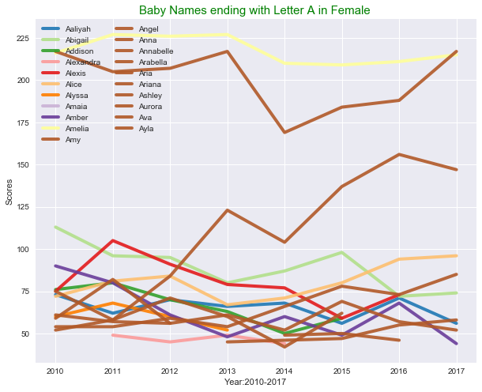

```python
plt.rcParams['figure.figsize']=(10,8)
plt.rcParams.update({'font.size':20})
plt.style.use('seaborn-darkgrid')

palette1 = plt.get_cmap('Paired')
df1=baby_names_female.reset_index()
df1=baby_names_female.drop(['sex'],axis=1)
df1=df1[(df1.index>=2010)&(df1.index<=2017)&(df1['Name'].astype(str).str[0]=='A')]
df1=df1.pivot_table(index=['year'],columns='Name',values='No.')
# multiple line plot
num=0
for column in df1.drop(df.index, axis=0):
    num+=1
    plt.plot(df1.index, df1[column], marker='', color=palette1(num), linewidth=4, alpha=0.9, label=column)

# Add legend
plt.legend(loc=2, ncol=2)

# Add titles
plt.title("Baby Names ending with Letter A in Female ", loc='center', fontsize=15, fontweight=0, color='green')
plt.xlabel("Year:2010-2017")
plt.ylabel("Scores")
```

# MINI REPORT

## Introduction

For the below data set which are New Zealand indicators based on various topics such as Income and wealth,poverty,housing,labour and health.Each one of these topics have their own columns for a specific group.For the basis of the analysis **Housing** and **Labour** are selected in this report.

**In Housing the following was analyzed:**

- Whether there is a trend in housing affortability in terms of rental and purchase?
- Comparison of distribution of 30% income spend on household costs vs 30% income spend on household rental.

**In Labour the following was analyzed:**

- Is unemployment rate, a contributor or influence towards long term unemployment?

```python
import re
#read file and standardised non standard missing values
nz_indicators = pd.read_csv('nz_indicators.csv',na_values=['???', '-', 'None', 'NAN','NULL', 'null', 'nan'])

#parsed Year column to datetime format
nz_indicators['year']=pd.to_datetime(nz_indicators['year'])

#reset and drop default index
nz_indicators=nz_indicators.reset_index(drop=True)

#set index to year
nz_indicators=nz_indicators.set_index(['year'])

#sorting year index
nz_indicators=nz_indicators.sort_index()

#used below commented code to check all cells for type of data whether they are string, float or int
#nz_indicators.applymap(type)

#function to clean all cells of unusual nuisance characters
def clean_cells(field):
    #checks if cells are  float or int and returns int or float
    if (type(field) == float) | (type(field)== int):
        return field
    #check for string cells for regular expression using regex findall loads value into object s
    #object s is then converted to float value and returned to cell
    elif type(field)== str:
        field = field.split(',')[0]
        [s] = re.findall(r'\d+\.*\d*', field)
        return float(s)

#using apply map to apply function to all cells
nz_indicators=nz_indicators.applymap(clean_cells)

#used to check for columns names for selection to be dropped
#nz_indicators.columns.unique()

to_drop=['Q5:Q1', 'D10:D1', 'D10:D1-4(Palma)', 'P90:P10_bhc', 'P80:P20_bhc',
       'P80:P50_bhc', 'P50:P20_bhc', 'GINI-BHC', 'top_10_perc_wealth_share',
       'top_5_perc_wealth_share', 'top_1_perc_wealth_share',
       'UN_middle_class_def_inc_share', 'OECD_middle_class_def_inc_share',
       'LIH_B60_contemp_median_AHC', 'LIH_B50_contemp_median_AHC',
       'LIH_B50_CV_AHC', 'LIH_B60_CV_AHC', 'LIH_B40_contemp_median_AHC',
       'LIEH_B60_contemp_median_AHC', 'LIEH_B50_contemp_median_AHC',
       'LIEH_B50_CV_median_AHC', 'LIEH_B60_CV_median_AHC',
       'LIS65H_B60_CV_median_AHC', 'LISPH_B60_CV_median_AHC',
       'LIS65H_B50_CV_median_AHC', 'LISPH_B50_CV_median_AHC',
       'child_poverty_ahc_perc_HH_B50_CV', 'child_poverty_ahc_perc_HH_B60_CV',
       'child_poverty_ahc_perc_HH_B40_contemp_median',
       'child_poverty_ahc_perc_HH_B50_contemp_median',
       'child_poverty_ahc_perc_HH_B60_contemp_median',
       'child_poverty_ahc_perc_HH_B60_CV_one_or_more_FT_working_parents',
       'child_poverty_ahc_perc_HH_B60_CV_one_or_more_PT_working_parents','teriary_education_participation_rate',
       'education_spend_as_percent_of_GDP',
       'education_spend_as_percent_of_total_gov_expenses',
       'median_teriary_loan_as_perc_of_med_inc_AHC',
       'median_teriary_loan_balance_as_perc_of_med_inc_AHC',
       'university_affordability_ratio_to_mean_salary',
       'polytechnics_affordability_ratio_to_mean_salary',
       'wananga_affordability_ratio_to_mean_salary',
       'bachelors_earning_premium_hourly', 'dips_cert_earning_premium_hourly',
       'school_earning_premium_hourly', 'bachelors_earning_premium_weekly',
       'dips_cert_earning_premium_weekly', 'school_earning_premium_weekly',
       'health_expenditure_as_percent_of_gdp',
       'health_expenditure_per_capita_PPP', 'depression_adult',
       'excellent_very_good_or_good_self_rated_health',
       'psychological_distress_adult', 'mood_anxiety_disorder_adult',
       'healthy_weight_adult', 'unmet_after_hours_care_due_to_cost_adult',
       'unmet_GP_care_due_to_cost_adult', 'veg_and_fruit_intake_adult',
       'breakfast_eaten_at_home_less_5_days_a_week_child',
       'emotional_behavioural_problems_child', 'adult_diabetes_rates',
       'depression_child',
       'excellent_very_good_or_good_parent_rated_health_child',
       'unfilled_prescription_due_to_cost_child',
       'unmet_need_for_after_hours_due_to_cost_child',
       'unmet_need_for_GP_due_to_cost_child',
       'vegetable_and_fruit_intake_child', 'healthy_weight_child',
       'suicides_per_100000',
       'problem_gambling_intervention_prevelance_percent']
nz_indicators=nz_indicators.drop(to_drop,axis=1)
#nz_indicators.head()
```

### After cleaning:

- Data has been prepared for topic of choice by dropping columns not required using drop function.
- Columns of interest relevant to each topic i.e for **Housing** and **Labour** is sliced so data is used only for previous 10 years from 2007 to 2017.This is because most columns have completed columns in terms of data.

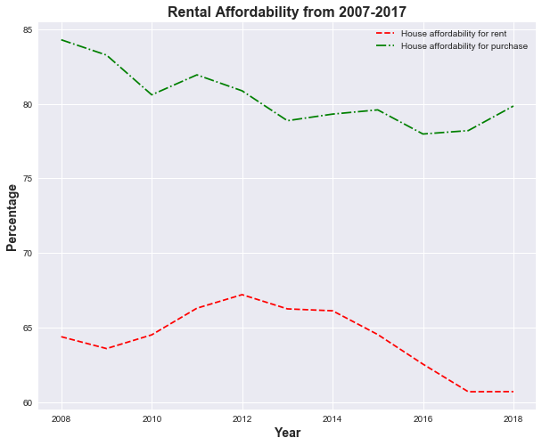

```python
#All objects added with sliced data as mentioned above and multiplied by 100 for plotting

nzi_rental_vs_income=(nz_indicators.loc['2007-12-31 ':'2017-12-31','national_house_rental_A30%_income_spend']*100)

nzi_owned_vs_income=(nz_indicators.loc['2007-12-31 ':'2017-12-31','national_house_purchasing_A30%_income_spend']*100)

nzi_rental_affordability=(nz_indicators.loc['2007-12-31 ':'2017-12-31','national_house_rental_HAM']*100)

nzi_ownership_affordability=(nz_indicators.loc['2007-12-31 ':'2017-12-31','national_house_purchasing_HAM']*100)

x2=nzi_rental_affordability

y2=nzi_ownership_affordability

plt.rcParams['figure.figsize']=(10,8)

plt.rcParams.update({'font.size':30})

plt.plot(x2,'--',color='red',label='House affordability for rent')

plt.plot(y2,'-.',color='green',label='House affordability for purchase')

plt.legend()

plt.xlabel("Year",fontsize=14,fontweight='bold')

plt.ylabel("Percentage",fontsize=14,fontweight='bold')

plt.title("Rental Affordability from 2007-2017",fontsize=16, fontweight='bold')
plt.show()
```

### FINDINGS:

**Housing affordability for rental had a slow increasing trend from 2008 till at it's peak at 2012 and has ever since on a decline. The most significant or steep decline was observed from 2014 till 2017.The trend in Housing affordability for purchase has been showing a consistent decline with slight peak between 2010-2011.**

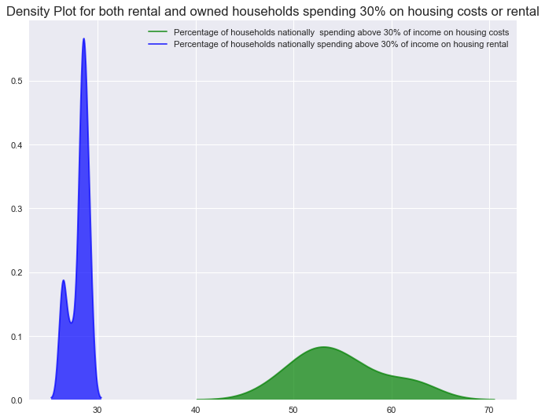

```python
plt.figure(figsize=(10,8), dpi= 80)
sns.kdeplot(nzi_owned_vs_income, shade=True, color="g", label="Percentage of households nationally  spending above 30% of income on housing costs", alpha=0.7)
sns.kdeplot(nzi_rental_vs_income, shade=True, color="b", label="Percentage of households nationally spending above 30% of income on housing rental", alpha=0.7)
plt.title('Density Plot for both rental and owned households spending 30% on housing costs or rental', fontsize=15)
plt.legend()
plt.show()
```

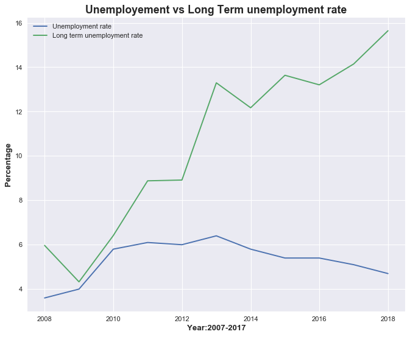

```python
nzi_unemployment_rate=nz_indicators.loc['2007-12-31 ':'2017-12-31','unemployment_rate']
nzi_longterm_unemployment_rate=nz_indicators.loc['2007-12-31 ':'2017-12-31','long_term_unemployment_rate']
plt.figure(figsize=(10,8), dpi= 80)
nzi_longterm_unemployment_rate
plt.plot(nzi_unemployment_rate, label="Unemployment rate")
plt.plot(nzi_longterm_unemployment_rate, label="Long term unemployment rate")
plt.legend(loc='upper left')
# Add title and x, y labels
plt.title("Unemployement vs Long Term unemployment rate", fontsize=16, fontweight='bold')
plt.xlabel("Year:2007-2017",fontsize=12,fontweight='bold')
plt.ylabel("Percentage",fontsize=12,fontweight='bold')
plt.show()
```

### Findings:

**The above visualization shows that long term employment has seen a sharp peak from 2009 till 2011 and then flattens till 2012 and peaks again till 2013 are keep incrementing steadily.Meanwhile, the underemployment rate has seen a steady increase till 2013 and a slow decrease from there on till 2017.**

## Conclusion:

**Hence the report concludes that in terms of Housing, the housing affordability for purchase is showing a semi-linear trend since 2013 after a downward trend previously.This will need to be investigated further as the data is not in a adequate span of years to extrapolate after 2017.Furthermore,there is notable decline in Housing affordability in terms of rental.One speculation or assumption may be shortage of rentals as population in cities increase.**

**Considering long term unemployement, the trend in unemployement seems to slightly effecting the trend in long term unemployement.The pace of decline in unemployment rate is having a very minimal effect on long term unemployement.**